# FIeld trials CA 2022_v1

JQP

2023-06-29

```r
raw<-read.csv("Exp_1_results_organized.csv")
str(raw)
```

```
## 'data.frame':    54 obs. of  16 variables:
##  $ Samples.ID        : chr  "Tis8" "Tis59" "Tis4" "Tis22" ...
##  $ Sample.Type       : chr  "Produce Sample" "Produce Sample" "Produce Sample" "Produce Sample" ...
##  $ Bed.number        : chr  "Edge Creek" "4" "Edge Creek" "1" ...
##  $ Hand.msd          : chr  "" "" "" "" ...
##  $ Wet.dry           : chr  "" "" "" "" ...
##  $ Top.bottom        : chr  "Top" "Top" "Bottom" "Top" ...
##  $ Date.collected    : chr  "6/27/2022" "6/27/2022" "6/27/2022" "6/27/2022" ...
##  $ Date.processed    : chr  "6/29/2022" "6/29/2022" "6/29/2022" "6/29/2022" ...
##  $ Weight.g.         : num  214 439 811 400 417 ...
##  $ PBS.added.ml.     : num  194 419 791 380 397 ...
##  $ Log.APC.          : num  5.67 5.76 5.3 5.15 4.95 ...
##  $ Log.Coli.         : num  6.12 5.83 4.26 4.62 4.08 ...
##  $ Log.E.coli.       : num  2.53 NA NA 3.15 2.3 ...
##  $ Log.APC.repeat.   : chr  "7.424458141" "7.278330106" "" "" ...
##  $ Log.Coli.repeat.  : chr  "7.389822118" "7.231394068" "" "" ...
##  $ Log.E.coli.repeat.: num  4.51 NA NA NA NA ...
```

```r
Fanoe<-read.csv("Experiment_1_trimmed.csv")
str(Fanoe)
```

```
## 'data.frame':    85 obs. of  18 variables:
##  $ Samples.ID    : chr  "Tis8" "Tis59" "Tis4" "Tis22" ...
##  $ Sample.Type   : chr  "Produce Sample" "Produce Sample" "Produce Sample" "Produce Sample" ...
##  $ Bed.number    : chr  "Edge Creek" "4" "Edge Creek" "1" ...
##  $ Hand.msd      : chr  NA NA NA NA ...
##  $ Wet.dry       : chr  NA NA NA NA ...
##  $ Top.bottom    : chr  "Top" "Top" "Bottom" "Top" ...
##  $ Date.collected: chr  "6/27/2022" "6/27/2022" "6/27/2022" "6/27/2022" ...
##  $ Date.processed: chr  "6/29/2022" "6/29/2022" "6/29/2022" "6/29/2022" ...
##  $ Weight.g.     : num  214 439 811 400 417 ...
##  $ PBS.added.ml. : num  194 419 791 380 397 ...
##  $ Log.APC.      : num  5.67 5.76 5.3 5.15 4.95 ...
##  $ Log.Coli.     : chr  "6.122875576" "5.826288443" "4.255272505" "4.62324929" ...
##  $ Log.E.coli.   : num  2.53 NA NA 3.15 2.3 ...
##  $ Opportunity   : chr  "Original" "Original" "Original" "Original" ...
##  $ Zone          : chr  "Edge Creek" "Center" "Edge Creek" "Center" ...
##  $ X             : logi  NA NA NA NA NA NA ...
##  $ X.1           : logi  NA NA NA NA NA NA ...
##  $ X.2           : chr  "" "" "" "" ...
```

```r
Fanoe$Zone<-as.factor(Fanoe$Zone)
Fanoe$Top.bottom<-as.factor(Fanoe$Top.bottom)
Fanoe$Wet.dry<-as.factor(Fanoe$Wet.dry)
Fanoe$Hand.msd<-as.factor(Fanoe$Hand.msd)
Fanoe$Opportunity<-as.factor(Fanoe$Opportunity)
Fanoe$Sample.Type<-as.factor(Fanoe$Sample.Type)
Fanoe$Log.Coli.<-as.numeric(Fanoe$Log.Coli.)
str(Fanoe) #This contains all original and repeated samples,
```

```
## 'data.frame':    85 obs. of  18 variables:
##  $ Samples.ID    : chr  "Tis8" "Tis59" "Tis4" "Tis22" ...
##  $ Sample.Type   : Factor w/ 2 levels "Aggregative Swab",..: 2 2 2 2 2 2 2 2 2 2 ...
##  $ Bed.number    : chr  "Edge Creek" "4" "Edge Creek" "1" ...
##  $ Hand.msd      : Factor w/ 2 levels "HAND","MSD": NA NA NA NA NA NA NA NA NA NA ...
##  $ Wet.dry       : Factor w/ 2 levels "DRY","WET": NA NA NA NA NA NA NA NA NA NA ...
##  $ Top.bottom    : Factor w/ 2 levels "Bottom","Top": 2 2 1 2 2 2 1 2 2 1 ...
##  $ Date.collected: chr  "6/27/2022" "6/27/2022" "6/27/2022" "6/27/2022" ...
##  $ Date.processed: chr  "6/29/2022" "6/29/2022" "6/29/2022" "6/29/2022" ...
##  $ Weight.g.     : num  214 439 811 400 417 ...
##  $ PBS.added.ml. : num  194 419 791 380 397 ...
##  $ Log.APC.      : num  5.67 5.76 5.3 5.15 4.95 ...
##  $ Log.Coli.     : num  6.12 5.83 4.26 4.62 4.08 ...
##  $ Log.E.coli.   : num  2.53 NA NA 3.15 2.3 ...
##  $ Opportunity   : Factor w/ 2 levels "Original","Repeat": 1 1 1 1 1 1 1 1 1 1 ...
##  $ Zone          : Factor w/ 2 levels "Center","Edge Creek": 2 1 2 1 1 1 2 2 2 1 ...
##  $ X             : logi  NA NA NA NA NA NA ...
##  $ X.1           : logi  NA NA NA NA NA NA ...
##  $ X.2           : chr  "" "" "" "" ...
```

```r
SumFanoe<-Fanoe%>%group_by(Sample.Type, Opportunity,Wet.dry, Hand.msd)%>%summarise(n=n())
```

```
## You can override using the `.groups` argument.
```

```r
knitr::kable(SumFanoe)
```

| Sample.Type | Opportunity | Wet.dry | Hand.msd | n |
| --- | --- | --- | --- | --- |
| Aggregative Swab | Original | DRY | MSD | 11 |
| Aggregative Swab | Original | WET | HAND | 6 |
| Aggregative Swab | Original | WET | MSD | 15 |
| Aggregative Swab | Repeat | DRY | MSD | 3 |
| Aggregative Swab | Repeat | WET | HAND | 4 |
| Aggregative Swab | Repeat | WET | MSD | 11 |
| Produce Sample | Original | NA | NA | 22 |
| Produce Sample | Repeat | NA | NA | 13 |

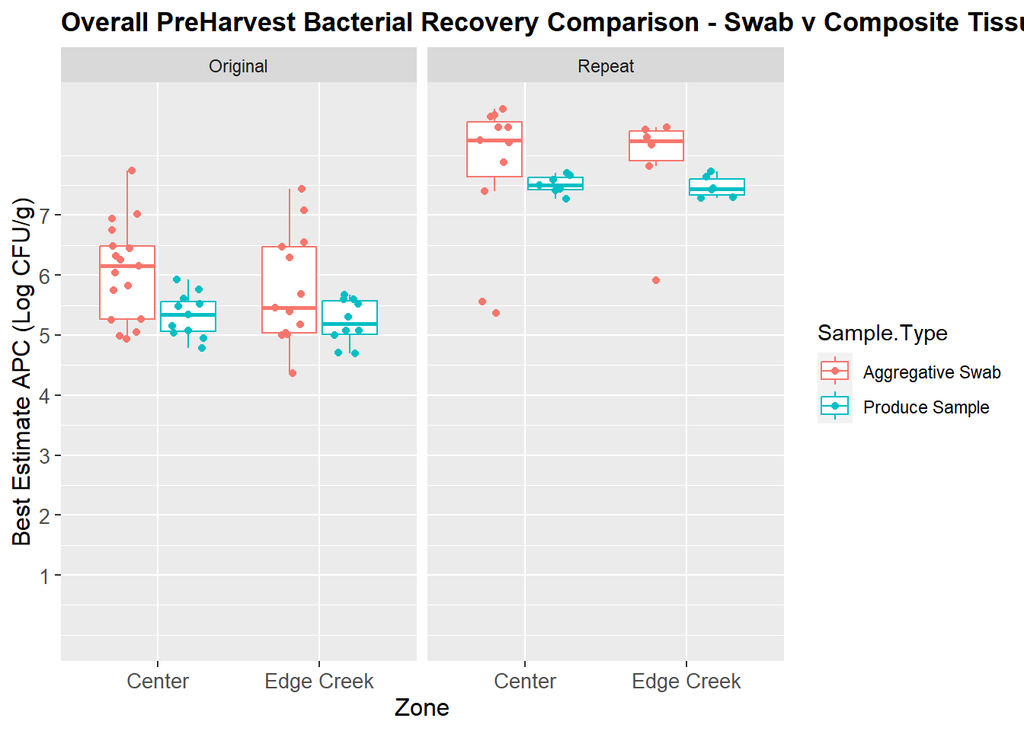

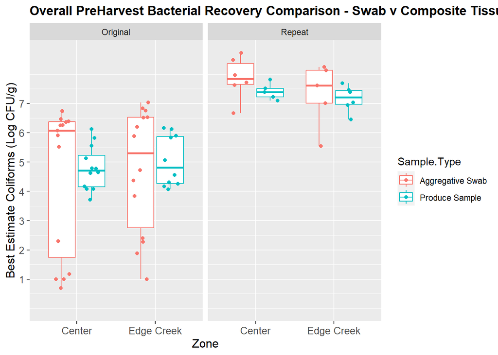

*Overall, higher APC and Coliforms on repeated samples, why?*

*However, following discussion on 07/11/22, we kept the originals and filled in the gaps with the repeated samples*

```r
adj_Fanoe<-read.csv("Experiment_1_adjusted trim.csv")
adj_Fanoe$Zone<-as.factor(adj_Fanoe$Zone)
adj_Fanoe$Top.bottom<-as.factor(adj_Fanoe$Top.bottom)
adj_Fanoe$Wet.dry<-as.factor(adj_Fanoe$Wet.dry)
adj_Fanoe$Hand.msd<-as.factor(adj_Fanoe$Hand.msd)
adj_Fanoe$Opportunity<-as.factor(adj_Fanoe$Opportunity)
adj_Fanoe$Sample.Type<-as.factor(adj_Fanoe$Sample.Type)
str(adj_Fanoe)
```

```
## 'data.frame':    54 obs. of  15 variables:
##  $ Samples.ID    : chr  "Tis8" "Tis59" "Tis4" "Tis22" ...
##  $ Sample.Type   : Factor w/ 2 levels "Aggregative Swab",..: 2 2 2 2 2 2 2 2 2 2 ...
##  $ Bed.number    : chr  "Edge Creek" "4" "Edge Creek" "1" ...
##  $ Hand.msd      : Factor w/ 2 levels "HAND","MSD": NA NA NA NA NA NA NA NA NA NA ...
##  $ Wet.dry       : Factor w/ 2 levels "DRY","WET": NA NA NA NA NA NA NA NA NA NA ...
##  $ Top.bottom    : Factor w/ 2 levels "Bottom","Top": 2 2 1 2 2 2 1 2 2 1 ...
##  $ Date.collected: chr  "6/27/2022" "6/27/2022" "6/27/2022" "6/27/2022" ...
##  $ Date.processed: chr  "6/29/2022" "6/29/2022" "6/29/2022" "6/29/2022" ...
##  $ Weight.g.     : num  214 439 811 400 417 ...
##  $ PBS.added.ml. : num  194 419 791 380 397 ...
##  $ Log.APC.      : num  5.67 5.76 5.3 5.15 4.95 ...
##  $ Log.Coli.     : num  6.12 5.83 4.26 4.62 4.08 ...
##  $ Log.E.coli.   : num  2.53 NA NA 3.15 2.3 ...
##  $ Opportunity   : Factor w/ 2 levels "Original","Repeat": 1 1 1 1 1 1 1 1 1 1 ...
##  $ Zone          : Factor w/ 2 levels "Center","Edge Creek": 2 1 2 1 1 1 2 2 2 1 ...
```

```r
wkngsamples_Fanoe<-adj_Fanoe%>%group_by(Sample.Type, Wet.dry, Hand.msd, Zone)%>%summarise(n=n())
```

[output not shown]

```r
totalecoli<-adj_Fanoe%>%group_by(Sample.Type, Log.E.coli.)%>%summarise(count=n())
knitr::kable(wkngsamples_Fanoe)
```

| Sample.Type | Wet.dry | Hand.msd | Zone | n |
| --- | --- | --- | --- | --- |
| Aggregative Swab | DRY | MSD | Center | 5 |
| Aggregative Swab | DRY | MSD | Edge Creek | 6 |
| Aggregative Swab | WET | HAND | Center | 3 |
| Aggregative Swab | WET | HAND | Edge Creek | 3 |
| Aggregative Swab | WET | MSD | Center | 9 |
| Aggregative Swab | WET | MSD | Edge Creek | 6 |
| Produce Sample | NA | NA | Center | 12 |
| Produce Sample | NA | NA | Edge Creek | 10 |

```r
knitr::kable(totalecoli)
```

| Sample.Type | Log.E.coli. | count |
| --- | --- | --- |
| Aggregative Swab | 1.977724 | 1 |
| Aggregative Swab | 2.462398 | 1 |
| Aggregative Swab | 3.230449 | 1 |
| Aggregative Swab | 3.633469 | 1 |
| Aggregative Swab | 3.806180 | 1 |
| Aggregative Swab | 4.267606 | 1 |
| Aggregative Swab | NA | 26 |
| Produce Sample | 1.342423 | 1 |
| Produce Sample | 1.505150 | 1 |
| Produce Sample | 2.301030 | 1 |
| Produce Sample | 2.531479 | 1 |
| Produce Sample | 2.602060 | 1 |
| Produce Sample | 2.698970 | 1 |
| Produce Sample | 2.903090 | 1 |
| Produce Sample | 3.146128 | 1 |
| Produce Sample | 3.300000 | 1 |
| Produce Sample | NA | 13 |

**Updated working dataset consists on 32 swabs and 22 produce samples, N=54. MSD Dry cloths n=11, Prehydrated cloths, hand n=6, Prehydrated cloths, MSD n= 15.** **Generic *E. coli* Neg swabs= 26, Pos swabs= 6; Neg Produce= 13, Pos produce= 9**

*Graphs for overall visualization of all samples, based on field parameters and head collection*

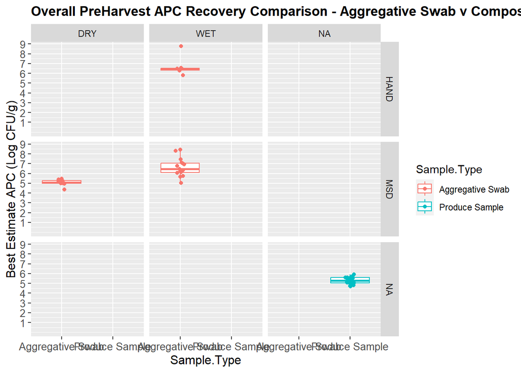

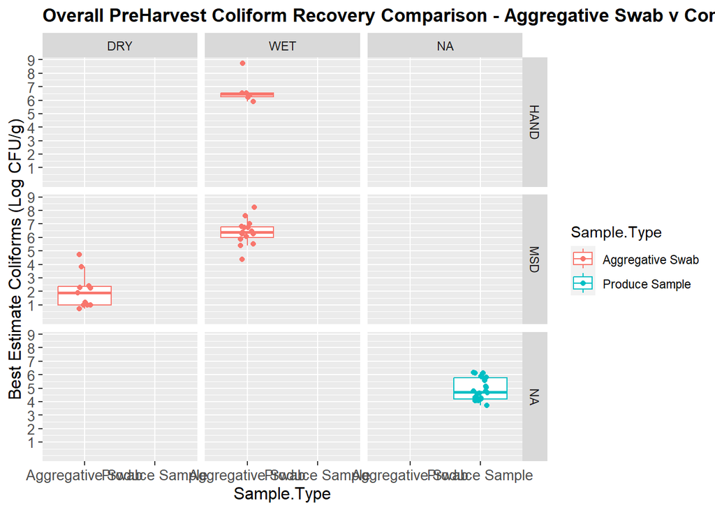

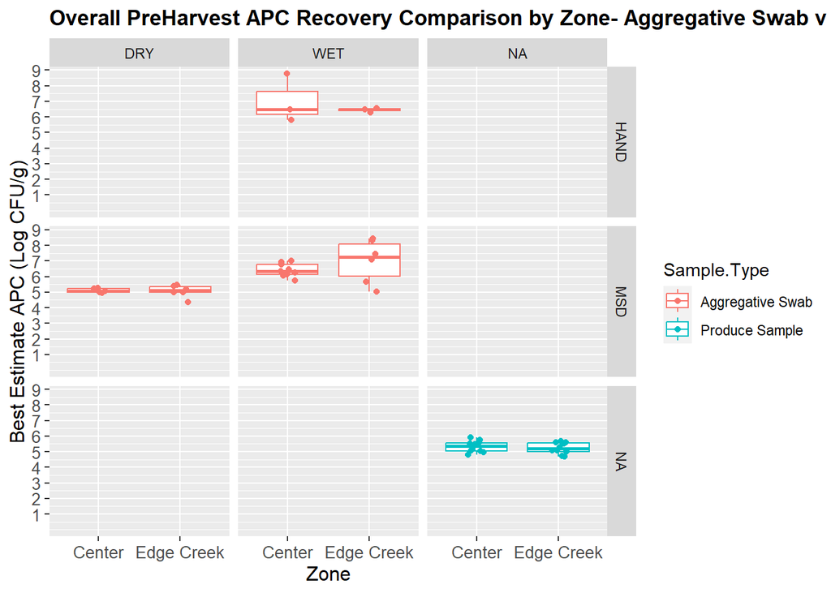

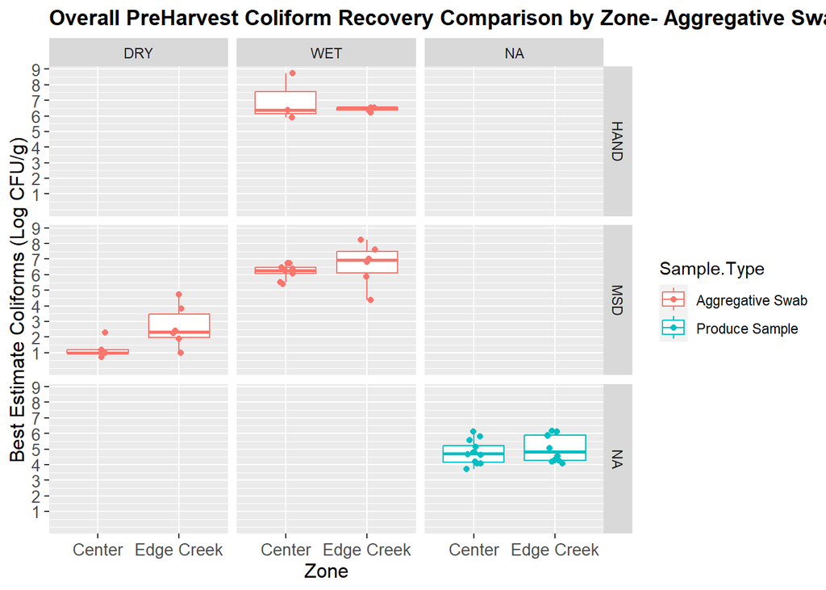

##Cleaning for analysis ###Analysis of Agg Swabs

```
## 'data.frame':    64 obs. of  14 variables:
##  $ ï..Samples.ID : chr  "MT23" "MT16" "MT10" "MT7" ...
##  $ Sample.Type   : Factor w/ 1 level "Aggregative Swab": 1 1 1 1 1 1 1 1 1 1 ...
##  $ Bed.number    : chr  "Edge Creek" "Edge Creek" "4" "6" ...
##  $ Hand.msd      : Factor w/ 2 levels "HAND","MSD": 2 2 2 2 2 2 2 2 2 2 ...
##  $ Wet.dry       : Factor w/ 2 levels "DRY","PREHYDRATED": 2 1 2 2 2 2 1 2 2 2 ...
##  $ Top.bottom    : Factor w/ 2 levels "Bottom","Top": 2 2 1 2 1 2 2 1 2 2 ...
##  $ Date.collected: chr  "6/27/2022" "6/27/2022" "6/27/2022" "6/27/2022" ...
##  $ Date.processed: chr  "6/29/2022" "6/29/2022" "6/29/2022" "6/29/2022" ...
##  $ Weight.g.     : num  31.1 16.9 31.6 30.8 39 ...
##  $ PBS.added.ml. : num  32.6 46.8 32.1 32.9 33.5 ...
##  $ Best..Estimate: num  7.08 5.01 7.02 6.45 6.05 ...
##  $ Test          : Factor w/ 2 levels "APC","Coliforms": 1 1 1 1 1 1 1 1 1 1 ...
##  $ Opportunity   : chr  "Original" "Original" "Original" "Original" ...
##  $ Zone          : Factor w/ 2 levels "Center","Edge Creek": 2 2 1 1 1 2 1 1 1 1 ...
```

```
## 'data.frame':    54 obs. of  14 variables:
##  $ Samples.ID    : chr  "Tis8" "Tis59" "Tis4" "Tis22" ...
##  $ Sample.Type   : Factor w/ 2 levels "Aggregative Swab",..: 2 2 2 2 2 2 2 2 2 2 ...
##  $ Bed.number    : chr  "Edge Creek" "4" "Edge Creek" "1" ...
##  $ Hand.msd      : Factor w/ 2 levels "HAND","MSD": NA NA NA NA NA NA NA NA NA NA ...
##  $ Wet.dry       : Factor w/ 2 levels "DRY","WET": NA NA NA NA NA NA NA NA NA NA ...
##  $ Top.bottom    : Factor w/ 2 levels "Bottom","Top": 2 2 1 2 2 2 1 2 2 1 ...
##  $ Date.collected: chr  "6/27/2022" "6/27/2022" "6/27/2022" "6/27/2022" ...
##  $ Date.processed: chr  "6/29/2022" "6/29/2022" "6/29/2022" "6/29/2022" ...
##  $ Weight.g.     : num  214 439 811 400 417 ...
##  $ PBS.added.ml. : num  194 419 791 380 397 ...
##  $ Log.APC.      : num  5.67 5.76 5.3 5.15 4.95 ...
##  $ Log.Coli.     : num  6.12 5.83 4.26 4.62 4.08 ...
##  $ Opportunity   : Factor w/ 2 levels "Original","Repeat": 1 1 1 1 1 1 1 1 1 1 ...
##  $ Zone          : Factor w/ 2 levels "Center","Edge Creek": 2 1 2 1 1 1 2 2 2 1 ...
```

####Visualization

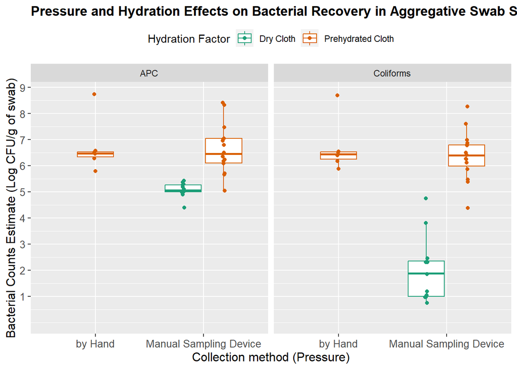

#Statistical Analysis - BASIC

#Summary ANOVA Tables for APC and Coliform counts

```r
knitr::kable(APC_BothFactors)
```

|  | Df | Sum Sq | Mean Sq | F value | Pr(>F) |
| --- | --- | --- | --- | --- | --- |
| Wet.dry | 1 | 18.2008234 | 18.2008234 | 28.6434487 | 0.0000095 |
| Hand.msd | 1 | 0.0331675 | 0.0331675 | 0.0521972 | 0.8208866 |
| Residuals | 29 | 18.4273858 | 0.6354271 | NA | NA |

```r
knitr::kable(APC_Zone_Effect)
```

|  | Df | Sum Sq | Mean Sq | F value | Pr(>F) |
| --- | --- | --- | --- | --- | --- |
| Wet.dry | 1 | 18.2008234 | 18.2008234 | 28.3848720 | 0.0000142 |
| Hand.msd | 1 | 0.0331675 | 0.0331675 | 0.0517260 | 0.8218657 |
| Zone | 1 | 0.1662596 | 0.1662596 | 0.2592881 | 0.6149043 |
| Hand.msd:Zone | 1 | 1.0029551 | 1.0029551 | 1.5641464 | 0.2221976 |
| Wet.dry:Zone | 1 | 0.5865649 | 0.5865649 | 0.9147701 | 0.3476612 |
| Residuals | 26 | 16.6716062 | 0.6412156 | NA | NA |

```r
knitr::kable(APC_InPlantLoc_effect)
```

|  | Df | Sum Sq | Mean Sq | F value | Pr(>F) |
| --- | --- | --- | --- | --- | --- |
| Wet.dry | 1 | 18.2008234 | 18.2008234 | 27.1478802 | 0.0000173 |
| Hand.msd | 1 | 0.0331675 | 0.0331675 | 0.0494718 | 0.8256589 |
| Top.bottom | 1 | 0.2821026 | 0.2821026 | 0.4207770 | 0.5220290 |
| Wet.dry:Top.bottom | 1 | 0.0436034 | 0.0436034 | 0.0650377 | 0.8006365 |
| Residuals | 27 | 18.1016797 | 0.6704326 | NA | NA |

```r
knitr::kable(Colif_BothFactors)
```

|  | Df | Sum Sq | Mean Sq | F value | Pr(>F) |
| --- | --- | --- | --- | --- | --- |
| Wet.dry | 1 | 143.3074836 | 143.3074836 | 123.34217 | 0.0000000 |
| Hand.msd | 1 | 0.4428465 | 0.4428465 | 0.38115 | 0.5418061 |
| Residuals | 29 | 33.6942112 | 1.1618694 | NA | NA |

```r
knitr::kable(Colif_Zone_Effect)
```

|  | Df | Sum Sq | Mean Sq | F value | Pr(>F) |
| --- | --- | --- | --- | --- | --- |
| Wet.dry | 1 | 143.3074836 | 143.3074836 | 139.6108662 | 0.0000000 |
| Hand.msd | 1 | 0.4428465 | 0.4428465 | 0.4314233 | 0.5170636 |
| Zone | 1 | 2.8575511 | 2.8575511 | 2.7838406 | 0.1072199 |
| Hand.msd:Zone | 1 | 2.6307697 | 2.6307697 | 2.5629090 | 0.1214792 |
| Wet.dry:Zone | 1 | 1.5174622 | 1.5174622 | 1.4783192 | 0.2349622 |
| Residuals | 26 | 26.6884282 | 1.0264780 | NA | NA |

```r
knitr::kable(Colif_InPlantLoc_effect)
```

|  | Df | Sum Sq | Mean Sq | F value | Pr(>F) |
| --- | --- | --- | --- | --- | --- |
| Wet.dry | 1 | 143.3074836 | 143.3074836 | 116.6056732 | 0.0000000 |
| Hand.msd | 1 | 0.4428465 | 0.4428465 | 0.3603330 | 0.5533269 |
| Top.bottom | 1 | 0.1299368 | 0.1299368 | 0.1057263 | 0.7475694 |
| Wet.dry:Top.bottom | 1 | 0.3814802 | 0.3814802 | 0.3104007 | 0.5820240 |
| Residuals | 27 | 33.1827942 | 1.2289924 | NA | NA |

#Hydration drives the attachment of bacteria to the cloth, hence, this will be the sampling technique ##Clean up dry swabs, keep the wet ones and compare them to produce ###Visualization

| Sample.Type | count |
| --- | --- |
| Aggregative Swab | 21 |
| Produce Sample | 22 |

| Sample.Type | Wet.dry | Test | count |
| --- | --- | --- | --- |
| Aggregative Swab | PREHYDRATED | APC | 21 |
| Aggregative Swab | PREHYDRATED | Coliforms | 21 |
| Produce Sample | NA | APC | 22 |
| Produce Sample | NA | Coliforms | 22 |

#Visuals

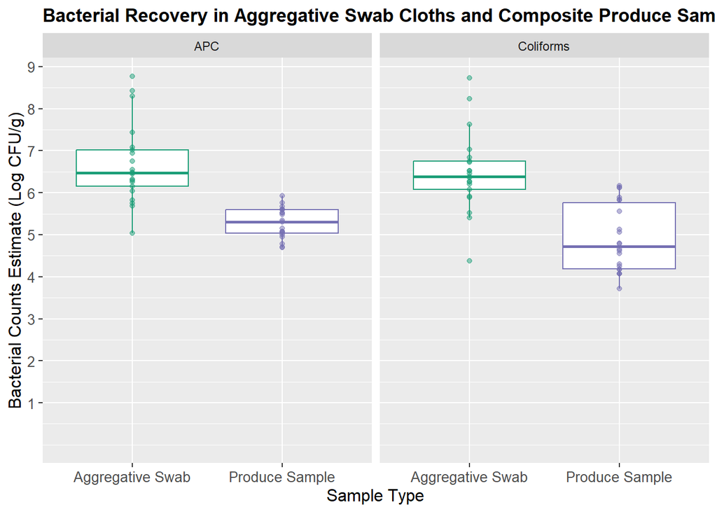

#Statistics

```r
knitr::kable(MTPS_SamTypeAPC)
```

|  | Df | Sum Sq | Mean Sq | F value | Pr(>F) |
| --- | --- | --- | --- | --- | --- |
| Sample.Type | 1 | 20.28656 | 20.2865596 | 40.29513 | 2e-07 |
| Residuals | 40 | 20.13797 | 0.5034494 | NA | NA |

```r
knitr::kable(MTPS_locAPC)
```

|  | Df | Sum Sq | Mean Sq | F value | Pr(>F) |
| --- | --- | --- | --- | --- | --- |
| Sample.Type | 1 | 20.2865596 | 20.2865596 | 38.9943262 | 0.0000003 |
| Zone | 1 | 0.0469786 | 0.0469786 | 0.0903012 | 0.7654326 |
| Sample.Type:Zone | 1 | 0.3217287 | 0.3217287 | 0.6184191 | 0.4365122 |
| Residuals | 38 | 19.7692674 | 0.5202439 | NA | NA |

```r
knitr::kable(MTPS_plantAPC)
```

|  | Df | Sum Sq | Mean Sq | F value | Pr(>F) |
| --- | --- | --- | --- | --- | --- |
| Sample.Type | 1 | 20.2865596 | 20.2865596 | 38.6426295 | 0.0000003 |
| Top.bottom | 1 | 0.0337679 | 0.0337679 | 0.0643224 | 0.8011574 |
| Sample.Type:Top.bottom | 1 | 0.1550141 | 0.1550141 | 0.2952770 | 0.5900323 |
| Residuals | 38 | 19.9491927 | 0.5249788 | NA | NA |

```r
knitr::kable(MTPS_APC_Overall)
```

|  | Df | Sum Sq | Mean Sq | F value | Pr(>F) |
| --- | --- | --- | --- | --- | --- |
| Sample.Type | 1 | 20.2865596 | 20.2865596 | 36.7605372 | 0.0000007 |
| Zone | 1 | 0.0469786 | 0.0469786 | 0.0851283 | 0.7722372 |
| Top.bottom | 1 | 0.0398414 | 0.0398414 | 0.0721951 | 0.7897909 |
| Sample.Type:Top.bottom | 1 | 0.1682854 | 0.1682854 | 0.3049439 | 0.5844116 |
| Sample.Type:Zone | 1 | 0.2788635 | 0.2788635 | 0.5053184 | 0.4820208 |
| Zone:Top.bottom | 1 | 0.3215001 | 0.3215001 | 0.5825786 | 0.4505673 |
| Sample.Type:Zone:Top.bottom | 1 | 0.5193680 | 0.5193680 | 0.9411278 | 0.3388391 |
| Residuals | 34 | 18.7631378 | 0.5518570 | NA | NA |

```r
knitr::kable(MTPS_SamTypeColif)
```

|  | Df | Sum Sq | Mean Sq | F value | Pr(>F) |
| --- | --- | --- | --- | --- | --- |
| Sample.Type | 1 | 26.57551 | 26.5755084 | 35.13775 | 5e-07 |
| Residuals | 41 | 31.00926 | 0.7563235 | NA | NA |

```r
knitr::kable(MTPS_locColif)
```

|  | Df | Sum Sq | Mean Sq | F value | Pr(>F) |
| --- | --- | --- | --- | --- | --- |
| Sample.Type | 1 | 26.5755084 | 26.5755084 | 33.9773055 | 0.0000009 |
| Zone | 1 | 0.4912541 | 0.4912541 | 0.6280780 | 0.4328559 |
| Sample.Type:Zone | 1 | 0.0139784 | 0.0139784 | 0.0178717 | 0.8943392 |
| Residuals | 39 | 30.5040323 | 0.7821547 | NA | NA |

```r
knitr::kable(MTPS_plantColif)
```

|  | Df | Sum Sq | Mean Sq | F value | Pr(>F) |
| --- | --- | --- | --- | --- | --- |
| Sample.Type | 1 | 26.5755084 | 26.5755084 | 35.1369820 | 0.0000007 |
| Top.bottom | 1 | 1.2700334 | 1.2700334 | 1.6791830 | 0.2026500 |
| Sample.Type:Top.bottom | 1 | 0.2419676 | 0.2419676 | 0.3199191 | 0.5748962 |
| Residuals | 39 | 29.4972638 | 0.7563401 | NA | NA |

```r
knitr::kable(MTPS_Colif_Overall)
```

|  | Df | Sum Sq | Mean Sq | F value | Pr(>F) |
| --- | --- | --- | --- | --- | --- |
| Sample.Type | 1 | 26.5755084 | 26.5755084 | 33.5392944 | 0.0000015 |
| Zone | 1 | 0.4912541 | 0.4912541 | 0.6199812 | 0.4363542 |
| Top.bottom | 1 | 1.4246106 | 1.4246106 | 1.7979124 | 0.1886031 |
| Sample.Type:Top.bottom | 1 | 0.3143096 | 0.3143096 | 0.3966705 | 0.5329041 |
| Sample.Type:Zone | 1 | 0.0721075 | 0.0721075 | 0.0910024 | 0.7646919 |
| Zone:Top.bottom | 1 | 0.1275948 | 0.1275948 | 0.1610295 | 0.6906501 |
| Sample.Type:Zone:Top.bottom | 1 | 0.8464615 | 0.8464615 | 1.0682664 | 0.3084265 |
| Residuals | 35 | 27.7329267 | 0.7923693 | NA | NA |

#Appendix